# The Impact of AI adoption on Canadian Wage - Subtopic 1: Provinces

## *Do wages in AI-related jobs grow differently across Canadian provinces?*

## Goals

The purpose of this analysis is to investigate wage trends in AI-related occupations across Canadian provinces between 2012 and 2024. Specifically, we aim to:

- Examine whether provinces with larger technology sectors, such as Ontario, Quebec, Alberta, and British Columbia, experience faster wage growth in AI-intensive occupations.
- Compare wage growth trends between urban and rural provinces to assess the potential widening of wage disparities.
- Visualize changes over time and across provinces to support workforce development insights.

## Introduction

**Context/Hypothesis:** The adoption of artificial intelligence is expected to influence the labor market differently depending on the regional concentration of technology jobs. Provinces with more AI-related positions may experience faster wage growth compared to provinces with smaller tech sectors.

## Problem Statement

We seek to answer the following questions:

- How have wages in AI-intensive occupations changed in Canadian provinces between 2012 and 2024?
- Are urban provinces with a higher concentration of AI-related jobs experiencing faster wage growth than rural provinces, potentially creating a wage gap?

**Significance:** Understanding these patterns helps policymakers and institutions design strategies to reduce regional wage disparities, support equitable workforce development, and ensure inclusive adaptation to AI-driven labor market changes.

```python
# Load required packages for data manipulation, analysis, and visualization
import pandas as pd
import numpy as np
import matplotlib.pyplot as plt
import os
import seaborn as sns
import warnings
```

## Getting started with the Canadian Wage data

**Data Context:**

Key variables include:

- Year: Tracks changes in wages over time.
- Average wage (CAD): Measures median hourly wages for technology occupations.
- Province: Identifies the region, grouped into urban and rural categories.

Occupations chosen are mainly from these categories:

- Information Technology Systems (example: database administrators, system managers)
- Data Software and Web Development (example: data scientists, web developers)
- Engineering and Technical Support Fields (example: civil engineers, data entry clerks)

These variables provide a clear view of how AI-related occupations affect wages across regions and occupation types.

Let's begin by loading the data into Python:

```python
# We load wage datasets for each year from 2012 to 2025. These datasets contain wage information by province and the NOC code
df_1 = pd.read_csv("data/wage2012.csv", low_memory=False)
df_2 = pd.read_csv("data/wage2013.csv", low_memory=False)
df_3 = pd.read_csv("data/wage2014.csv", low_memory=False)
df_4 = pd.read_csv("data/wage2015.csv", low_memory=False)
df_5 = pd.read_csv("data/wage2016.csv", low_memory=False)
df_6 = pd.read_csv("data/wage2017.csv", encoding="windows-1252", low_memory=False)
df_7 = pd.read_csv("data/wage2018.csv", encoding="windows-1252", low_memory=False)
df_8 = pd.read_csv("data/wage2019.csv", low_memory=False)
df_9 = pd.read_csv("data/wage2020.csv", low_memory=False)
df_10 = pd.read_csv("data/wage2021.csv", low_memory=False)
df_11 = pd.read_csv("data/wage2022.csv", low_memory=False)
df_12 = pd.read_csv("data/wage2023.csv", low_memory=False)
df_13 = pd.read_csv("data/wage2024.csv", low_memory=False)
df_14 = pd.read_csv("data/wage2025.csv", low_memory=False)
```

After loading the provincial wage datasets, we added a **Year** column to each dataset. This step ensures that observations from different data files can be combined and analyzed as a single time series, allowing us to track wage changes over time from 2012 to 2025.

```python
# Add a seperate "Year" column to each dataset to track the year of observation
df_1["Year"] = "2012"
df_2["Year"] = "2013"
df_3["Year"] = "2014"
df_4["Year"] = "2015"
df_5["Year"] = "2016"
df_6["Year"] = "2017"
df_7["Year"] = "2018"
df_8["Year"] = "2019"
df_9["Year"] = "2020"
df_10["Year"] = "2021"
df_11["Year"] = "2022"
df_12["Year"] = "2023"
df_13["Year"] = "2024"
df_14["Year"] = "2025"
```

## Pre-processing data to simplify analysis moving forward

**Data Cleaning and Processing:**

1. **Standardization:** Column names, province abbreviations, and NOC codes were standardized across all datasets. NOC codes from 2021 were mapped back to 2016 equivalents to ensure consistency.
2. **Selection:** Only AI-related NOC codes relevant to the research were retained.
3. **Handling Missing Data:** Missing values were removed under the assumption that no wage data was recorded for that year or occupation.
4. **Merging:** All cleaned datasets were combined into a unified dataset for 2012–2025.
5. **Classification:** Provinces were classified as urban or rural to enable comparative analysis.
6. **Calculation of Averages:** For each province and year, the average median wage per hour was calculated.

```python
#This shows the uncleaned data of the column names provided in the full data set
df_list = [df_1, df_2, df_3, df_4, df_5, df_6, df_7, df_8, df_9, df_10, df_11, df_12, df_13, df_14]
df_columns = [df.columns.tolist() for df in df_list]
unique_values = set(item for sublist in df_columns for item in sublist)
unique_values
```

```
{'Annual Wage Flag_Salaire annuel',
 'Annual_Wage',
 'Annual_Wage_Flag_Salaire_annuel',
 'Average_Wage_Salaire_Moyen',
 'Commentaire_Salaire',
 'Data Source',
 'Data_Source_E',
 'Data_Source_F',
 'ER Code_Code RE',
 'ER Name_Nom RE',
 'ER_Code',
 'ER_Code_Code_RE',
 'ER_Name',
 'ER_Name_Nom_RE',
 'Economic_Region',
 'EmployeesWithNonWageBenefit_Pct',
 'High Wage_Salaire maximal',
 'High_Wage_Salaire_Maximal',
 'Low Wage_Salaire Minium',
 'Low_Wage_Salaire_Minium',
 'Median wage_Salaire Median',
 'Median_Wage_Salaire_Median',
 'NOC Title',
 'NOC_CNP',
 'NOC_CNP_2006',
 'NOC_TITLE_ENG',
 'NOC_TITLE_FRA',
 'NOC_Title',
 'NOC_Title_E',
 'NOC_Title_F',
 'NOC_Title_eng',
 'NOC_Title_fra',
 'Nom_RE',
 'Non_WageBen_pct',
 'PROV',
 'Prov',
 'Quartile1_Wage_Salaire_Quartile1',
 'Quartile3_Wage_Salaire_Quartile3',
 'Reference Period_Periode de reference',
 'Reference_Period',
 'Revision Date_Date revision',
 'Revision_Date_Date_revision',
 'Source de donnees',
 'Source2025_NHQ',
 'Titre CNP',
 'Titre_CNP',
 'Wage_Comment',
 'Wage_Comment_E',
 'Wage_Comment_F',
 'Wage_Comment_F1',
 'Year',
 'prov'}
```

The column names were first inspected across all yearly datasets to identify inconsistencies caused by varying labels, abbreviations, and formatting differences. Based on this inspection, key variables were standardized to ensure consistency before merging the datasets.

```python
# Different datasets use slightly different column names (English/French, abbreviations)
# We standardize column names to unify all datasets, focusing on "Median_Wage", "Province", and "NOC_CNP"

rename_map = {
        "Median_Wage_Salaire_Median": "Median_Wage",
        "PROV": "Province",
        "NOC_CNP_2006": "NOC_CNP",
        "Prov": "Province",
        "prov": "Province",
        "Median wage_Salaire Median": "Median_Wage",
}

df_1 = df_1.rename(columns=rename_map)
df_2 = df_2.rename(columns=rename_map)
df_3 = df_3.rename(columns=rename_map)
df_4 = df_4.rename(columns=rename_map)
df_5 = df_5.rename(columns=rename_map)
df_6 = df_6.rename(columns=rename_map)
df_7 = df_7.rename(columns=rename_map)
df_8 = df_8.rename(columns=rename_map)
df_9 = df_9.rename(columns=rename_map)
df_10 = df_10.rename(columns=rename_map)
df_11 = df_11.rename(columns=rename_map)
df_12 = df_12.rename(columns=rename_map)
df_13 = df_13.rename(columns=rename_map)
df_14 = df_14.rename(columns=rename_map)

df_1["NOC_CNP"] = df_1["NOC_CNP"].astype(str)
df_3["NOC_CNP"] = df_3["NOC_CNP"].astype(str)
```

After standardizing the column names, we examined province names across all datasets to identify inconsistencies such as abbreviations and alternate spellings. This step helps ensure provinces are classified consistently before going through the analysis.

```python
#This shows the uncleaned data of the provinces names provided in the full data set
possible_cols = ["Province", "prov", "pr"]   # filters only province keywords

province_values = []

for df in df_list:
    for col in df.columns:
        if any(key in col.lower() for key in possible_cols):
            province_values.extend(df[col].unique())

unique_provinces = set(province_values)
unique_provinces
```

```
{'AB',
 'Alberta',
 'BC',
 'British Columbia',
 'CA',
 'MB',
 'Manitoba',
 'NAT',
 'NB',
 'NL',
 'NS',
 'NT',
 'NU',
 'NW',
 'NWT',
 'National',
 'New Brunswick',
 'Newfoundland and Labrador',
 'Northwest Territories',
 'Nova Scotia',
 'Nunavut',
 'ON',
 'Ontario',
 'PE',
 'PEI',
 'Prince Edward Island',
 'QC',
 'Quebec',
 'Québec',
 'SK',
 'Saskatchewan',
 'YK',
 'YT',
 'Yukon Territory',
 nan}
```

Provinces appear in multiple different formats across datasets, including abbreviations, full names, and labels with accents. To ensure consistency in analysis and grouping, we maped all variations to a standardized set of province names.

```python
# Provinces are listed in multiple formats (abbreviations, full names)
# We map all variations to a consistent province name for accurate grouping and comparison
province_map = {
    "CA": "Canada",
    "NL": "Newfoundland and Labrador",
    "PE": "Prince Edward Island",
    "PEI": "Prince Edward Island",
    "NS": "Nova Scotia",
    "NB": "New Brunswick",
    "QC": "Quebec",
    "Québec": "Quebec",
    "Yukon Territory": "Yukon",
    "National": "Canada",
    "ON": "Ontario",
    "MB": "Manitoba",
    "SK": "Saskatchewan",
    "AB": "Alberta",
    "BC": "British Columbia",
    "YT": "Yukon",
    "YK": "Yukon",
    "NT": "Northwest Territories",
    "NU": "Nunavut",
    "NW": "Northwest Territories",
    "NAT": "National",
    "NWT": "Northwest Territories"
}

df_1["Province"] = df_1["Province"].replace(province_map)
df_2["Province"] = df_2["Province"].replace(province_map)
df_3["Province"] = df_3["Province"].replace(province_map)
df_4["Province"] = df_4["Province"].replace(province_map)
df_5["Province"] = df_5["Province"].replace(province_map)
df_6["Province"] = df_6["Province"].replace(province_map)
df_7["Province"] = df_7["Province"].replace(province_map)
df_8["Province"] = df_8["Province"].replace(province_map)
df_9["Province"] = df_9["Province"].replace(province_map)
df_10["Province"] = df_10["Province"].replace(province_map)
df_11["Province"] = df_11["Province"].replace(province_map)
df_12["Province"] = df_12["Province"].replace(province_map)
df_13["Province"] = df_13["Province"].replace(province_map)
df_14["Province"] = df_14["Province"].replace(province_map)
```

NOC codes have inconsistent formats across datasets (e.g., some have 2, 3, or 4 digits). We standardize them by adding leading zeros and a "NOC_" prefix to ensure uniformity.

```python
#NOC codes arrangements

df_1["NOC_CNP"] = df_1["NOC_CNP"].apply(lambda x: "NOC_"+x if len(x) == 4 else ("NOC_00"+x if len(x) == 2 else "NOC_0"+x))
df_3["NOC_CNP"] = df_3["NOC_CNP"].apply(lambda x: "NOC_"+x if len(x) == 4 else ("NOC_00"+x if len(x) == 2 else "NOC_0"+x))
```

We keep only the columns needed for analysis: Year, NOC code, Province, and Median Wage. This simplifies the datasets and ensures consistency across all years.

```python
#Selected the columns we need from the datasets

df_1 = df_1[["Year", "NOC_CNP", "Province", "Median_Wage"]]
df_2 = df_2[["Year", "NOC_CNP", "Province", "Median_Wage"]]
df_3 = df_3[["Year", "NOC_CNP", "Province", "Median_Wage"]]
df_4 = df_4[["Year", "NOC_CNP", "Province", "Median_Wage"]]
df_5 = df_5[["Year", "NOC_CNP", "Province", "Median_Wage"]]
df_6 = df_6[["Year", "NOC_CNP", "Province", "Median_Wage"]]
df_7 = df_7[["Year", "NOC_CNP", "Province", "Median_Wage"]]
df_8 = df_8[["Year", "NOC_CNP", "Province", "Median_Wage"]]
df_9 = df_9[["Year", "NOC_CNP", "Province", "Median_Wage"]]
df_10 = df_10[["Year", "NOC_CNP", "Province", "Median_Wage"]]
df_11 = df_11[["Year", "NOC_CNP", "Province", "Median_Wage"]]
df_12 = df_12[["Year", "NOC_CNP", "Province", "Median_Wage"]]
df_13 = df_13[["Year", "NOC_CNP", "Province", "Median_Wage"]]
df_14 = df_14[["Year", "NOC_CNP", "Province", "Median_Wage"]]
```

```python
#list of datasets
df_list = [df_1, df_2, df_3, df_4, df_5, df_6, df_7, df_8, df_9, df_10, df_11, df_12, df_13, df_14]

# Some NOC codes have changed over time. We map older codes to current codes and filter only AI-related occupations for analysis
noc_mapping = {
    "NOC_21222": "NOC_2171",
    "NOC_22222": "NOC_2283",
    "NOC_20012": "NOC_0213",
    "NOC_22220": "NOC_2281",
    "NOC_21223": "NOC_2172",
    "NOC_21211": "NOC_2172",
    "NOC_21233": "NOC_2171",
    "NOC_21234": "NOC_2175",
    "NOC_21230": "NOC_2174",
    "NOC_21210": "NOC_2161",
    "NOC_21220": "NOC_2171",
    "NOC_21300": "NOC_2131",
    "NOC_21301": "NOC_2132",
    "NOC_21310": "NOC_2133",
    "NOC_21311": "NOC_2147",
    "NOC_21320": "NOC_2134",
    "NOC_21321": "NOC_2132",
    "NOC_22310": "NOC_2241",
    "NOC_22301": "NOC_2232",
    "NOC_22302": "NOC_2233",
    "NOC_22312": "NOC_2243",
    "NOC_92100": "NOC_9241",
    "NOC_14111": "NOC_1422"
}

noc_codes = [
    "NOC_2171", "NOC_2283", "NOC_0213", "NOC_2281", "NOC_2172", "NOC_2173", "NOC_2175", "NOC_2174", "NOC_2161",
    "NOC_2131", "NOC_2132", "NOC_2133", "NOC_2147", "NOC_2134", "NOC_2142", "NOC_2241", "NOC_2232", "NOC_2233",
    "NOC_2243", "NOC_1422", "NOC_8252"]

# For each dataframe, replace the NOC code by the correct ones
# Drop the missing values(since the data might not be recorded for that year we decided to drop them)
# Filter out the NOC codes that we do not need
for i in range(14):
    df_list[i] = df_list[i].replace(noc_mapping)
    df_list[i] = df_list[i].dropna(how="any")
    df_list[i] = df_list[i][df_list[i]["NOC_CNP"].isin(noc_codes)]

# After cleaning and filtering, we combine all annual datasets into a single dataset covering 2012–2025
wage_2012_2025 = pd.concat(df_list)
warnings.filterwarnings("ignore")
```

We categorize provinces into urban and rural groups to analyze wage trends by region type. Only selected provinces are included, and the 'Region_Type' column is added to differentiate urban vs. rural areas. We also ensure that 'Year' and 'Median_Wage' columns have the correct numeric data types for further analysis.

```python
#Classified Urban VS. Rural Provinces
urban_provs = ["Ontario", "Quebec", "British Columbia", "Alberta"]
rural_provs = ["Saskatchewan", "Manitoba", "Newfoundland and Labrador",
               "Nova Scotia", "New Brunswick", "Prince Edward Island"]

wage_2012_2025 = wage_2012_2025[wage_2012_2025["Province"].isin(urban_provs+rural_provs)]
wage_2012_2025["Region_Type"] = wage_2012_2025["Province"].apply(lambda x: "Urban" if x in urban_provs else ("Rural" if x in rural_provs else "Other"))
wage_2012_2025["Year"] = wage_2012_2025["Year"].astype(int)
wage_2012_2025["Median_Wage"] = wage_2012_2025["Median_Wage"].astype(float)
```

## Exploratory Data Analysis (EDA)

In this section, we explore the cleaned wage dataset from 2012 to 2025.  
We aim to:

- Examine summary statistics for key columns ('Median_Wage', 'Province', 'NOC_CNP').
- Identify all unique provinces and NOC codes in the dataset.
- Visualize the distribution of median wages using histograms.
- Compare median wages across urban and rural regions using boxplots.

This helps us understand the overall patterns and variability in wages before further analysis.

```
SUMMARY TABLE:
```

|  | count | mean | std | min | 25% | 50% | 75% | max | unique_provinces | unique_NOC |
| --- | --- | --- | --- | --- | --- | --- | --- | --- | --- | --- |
| Year | 11194.0 | 2018.915133 | 4.169565 | 2012.00 | 2015.0 | 2019.00 | 2023.0 | 2025.00 | 10 | 21 |
| Median_Wage | 11194.0 | 35.971153 | 9.361749 | 11.91 | 30.0 | 36.06 | 42.0 | 70.51 | 10 | 21 |

```
UNIQUE PROVINCES:
1. Newfoundland and Labrador
2. Prince Edward Island
3. Nova Scotia
4. New Brunswick
5. Quebec
6. Ontario
7. Manitoba
8. Saskatchewan
9. Alberta
10. British Columbia

UNIQUE NOC CODES:
1. NOC_0213
2. NOC_1422
3. NOC_2131
4. NOC_2132
5. NOC_2133
6. NOC_2134
7. NOC_2142
8. NOC_2147
9. NOC_2161
10. NOC_2171
11. NOC_2172
12. NOC_2173
13. NOC_2174
14. NOC_2175
15. NOC_2232
16. NOC_2233
17. NOC_2241
18. NOC_2243
19. NOC_2281
20. NOC_2283
21. NOC_8252
```

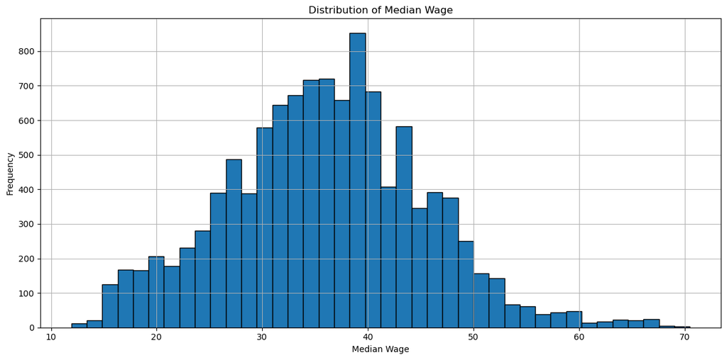

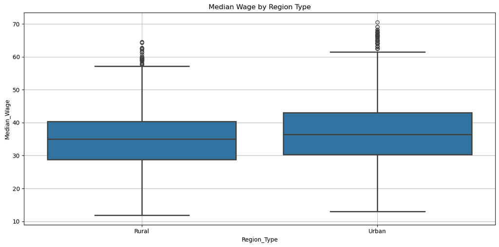

```python
#  EDA Analysis (Exploratory Data Analysis)

# Summary statistics
summary_stats = wage_2012_2025.describe().transpose()  # Uses transpose for readability
summary_stats["unique_provinces"] = [wage_2012_2025["Province"].nunique()] * len(summary_stats)
summary_stats["unique_NOC"] = [wage_2012_2025["NOC_CNP"].nunique()] * len(summary_stats)

print("\nSUMMARY TABLE:")
display(summary_stats)

# Unique provinces
unique_provinces = wage_2012_2025["Province"].unique()
print("\nUNIQUE PROVINCES:")
i = 1
for province in unique_provinces:
    print(f"{i}. {province}")
    i += 1

# Unique NOC codes
unique_noc = wage_2012_2025["NOC_CNP"].unique()
print("\nUNIQUE NOC CODES:")
i = 1
for noc in unique_noc:
    print(f"{i}. {noc}")
    i += 1

# Histogram of median wage
plt.figure(figsize=(12,6))
plt.hist(
    wage_2012_2025["Median_Wage"],
    bins=40,
    edgecolor="black",
    linewidth=1
)
plt.title("Distribution of Median Wage")
plt.xlabel("Median Wage")
plt.ylabel("Frequency")
plt.grid(True, linewidth=0.7)
plt.tight_layout()
plt.show()

# Boxplot by region type
plt.figure(figsize=(12,6))
sns.boxplot(
    data=wage_2012_2025,
    x="Region_Type",
    y="Median_Wage",
    linewidth=2
)
plt.title("Median Wage by Region Type")
plt.grid(True, linewidth=0.7)
plt.tight_layout()
plt.show()
```

## Exploratory Data Analysis (EDA) Findings

**Data Cleaning and Processing:**

To better understand the relationship between time, wages, and region type, we conduct a correlation analysis.

- The data is split into **urban** and **rural** provinces to examine whether wage trends behave differently across regions.
- Correlation is used to measure the **strength and direction of linear relationships**, not the size of wage growth.
- This section analyzes:
- The relationship between **year and median wage**
- The relationship between **urban and rural wage movements over time**

```python
# Correlation Analysis

# Split the data into urban and rural
urban_data = wage_2012_2025[wage_2012_2025["Region_Type"] == "Urban"]
rural_data = wage_2012_2025[wage_2012_2025["Region_Type"] == "Rural"]

# Simple correlation matrix for numeric columns
print("\nCorrelation Matrix:")
print(f"{wage_2012_2025[["Year", "Median_Wage"]].corr()}\n")

# Merge on year to compare wages year-by-year
urban_rural_merge = pd.merge(
    urban_data[["Year", "Median_Wage"]],
    rural_data[["Year", "Median_Wage"]],
    on="Year",
    suffixes=("_Urban", "_Rural")
)

# Correlation between urban and rural wages
urban_rural_corr = urban_rural_merge["Median_Wage_Urban"].corr(
    urban_rural_merge["Median_Wage_Rural"]
)

print("Correlation Between Urban and Rural Median Wages:", urban_rural_corr)

# Correlation of Year vs Median Wage for each region type
for region in wage_2012_2025["Region_Type"].unique():
    subset = wage_2012_2025[wage_2012_2025["Region_Type"] == region]
    corr_value = subset["Year"].corr(subset["Median_Wage"])
    print(f"Correlation between Year and Median Wage for {region}: {corr_value}")
```

```
Correlation Matrix:
                Year  Median_Wage
Year         1.00000      0.40415
Median_Wage  0.40415      1.00000

Correlation Between Urban and Rural Median Wages: 0.1979831423037141
Correlation between Year and Median Wage for Rural: 0.44095478283527945
Correlation between Year and Median Wage for Urban: 0.39610401384054295
```

Now, we are going to calculate the average median wage for each province for every year, grouped by region type (Urban vs Rural). This will help us analyze trends over time and compare wages across provinces and regions.

```python
# Compute Average Median Wage by Province and Year
avg_by_prov = wage_2012_2025.groupby(["Year","Province","Region_Type"])["Median_Wage"].mean().reset_index()
```

Now we are going to plot a line plot that shows the average median wage for each urban province from 2012 to 2025. It helps visualize how wages have changed over time across Ontario, Quebec, British Columbia, and Alberta.

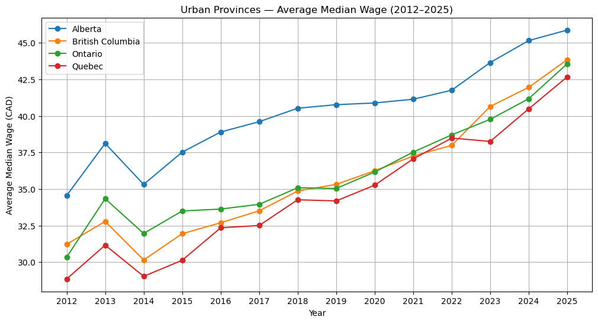

```python
# Plot a line graph for Urban Provinces

urban_df = avg_by_prov[avg_by_prov["Region_Type"]=="Urban"]
plt.figure(figsize=(12,6))
for prov in urban_df["Province"].unique():
    subset = urban_df[urban_df["Province"]==prov]
    plt.plot(subset["Year"], subset["Median_Wage"], marker='o', label=prov)

plt.title("Urban Provinces — Average Median Wage (2012–2025)")
plt.xlabel("Year")
plt.ylabel("Average Median Wage (CAD)")
plt.xticks(range(2012,2026))
plt.grid(True)
plt.legend()
plt.show()
```

Next, we are going to plot a line plot that shows the average median wage for each rural province from 2012 to 2025. It helps visualize how wages have changed over time across Manitoba, New Brunswick, Newfoundland and Labrador, Nova Scotia, Prince Edward Island, Saskatchewan

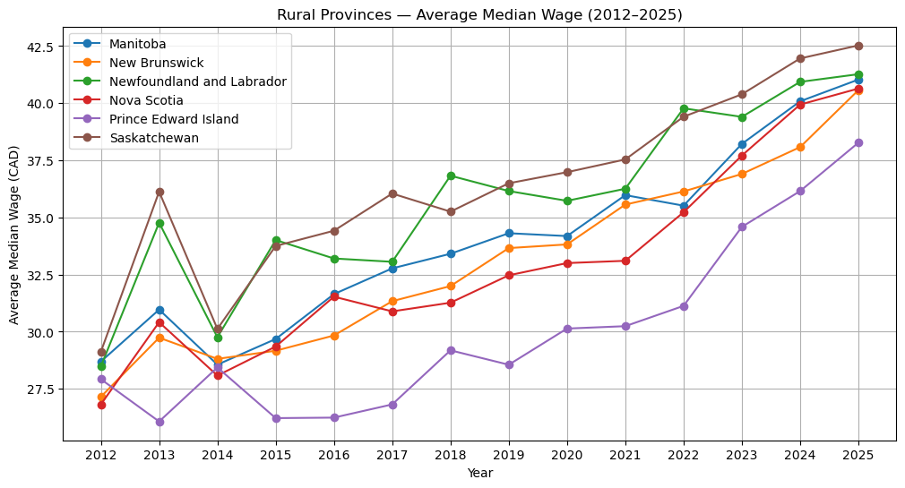

```python
# Plot a line graph for Rural Provinces

rural_df = avg_by_prov[avg_by_prov["Region_Type"]=="Rural"]
plt.figure(figsize=(12,6))
for prov in rural_df["Province"].unique():
    subset = rural_df[rural_df["Province"]==prov]
    plt.plot(subset["Year"], subset["Median_Wage"], marker='o', label=prov)

plt.title("Rural Provinces — Average Median Wage (2012–2025)")
plt.xlabel("Year")
plt.ylabel("Average Median Wage (CAD)")
plt.xticks(range(2012,2026))
plt.grid(True)
plt.legend()
plt.show()
```

## Urban VS. Rural Province Findings

- Line Graphs: Two primary line graphs were created: one for urban provinces and one for rural provinces.
- X-axis: Year (2012–2025)
- Y-axis: Average median wage (CAD)
- Lines: Different provinces represented using different colors

This visualization approach allows clear comparison of wage trends over time and highlights differences between urban and rural provinces.

## Key Takeaways

In this case, we analyzed wage trends in AI-related occupations across Canadian provinces using Python. Specifically, we:

- Cleaned and standardized multi-year provincial wage data (2012–2025)
- Filtered the dataset to focus on AI-intensive occupations
- Grouped provinces into urban and rural regions for comparison
- Used summary statistics, visualizations, and correlation analysis to examine wage patterns